# Project 2 Writeup

Max Machalek

March 6, 2018

Code adapted and re-used from Dr. Alex Buerkle, UWYO.

```r
#read the data in and store it as "cmv"
cmv<-read.csv("http://www.uwyo.edu/buerkle/compbio/statlabs/data/hcmv.data.txt")$location
```

```r
#plot a histogram of palindromes with bin sizes of 2500 base pairs
hist(cmv, breaks=seq(0, 230000, by=2500), xlim = c(1, 250000), ylim = c(1, 15),
     main = "(fig. 1) palindrome frequency by location, bin size = 2500",
     xlab = "Location (number of base pairs relative to start)",labels=T)
#paste probability of the cluster of 13 in a bin size of 2500
#based on ppois()
text(x=120000, y = 13, labels = paste("p = .00003"))
```

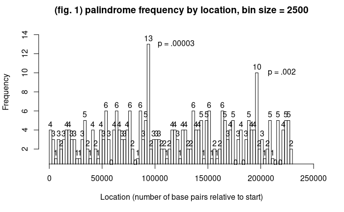

```r
#paste probability of the cluster of 10 in a bin size of 2500
#based on ppois()
text(x=220000, y = 10, labels = paste("p = .002"))
```

```r
#################################################################################
#plot a histogram of palindromes with bin sizes of 5000 base pairs
hist(cmv, breaks=seq(0, 230000, by=5000), xlim = c(1, 250000), ylim = c(1, 20),
     main = "(fig. 2) palindrome frequency by location, bin size = 5000",
     xlab = "Location (number of base pairs relative to start)",labels=T)
#paste probability of the cluster of 18 in a bin size of 5000
#based on ppois()
text(x=120000, y = 18, labels = paste("p = .000046"))
```

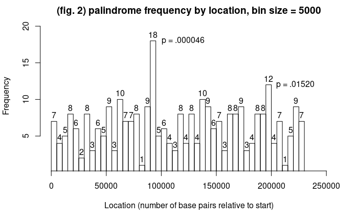

```r
#paste probability of the cluster of 12 in a bin size of 5000
#based on ppois()
text(x=222000, y = 12, labels = paste("p = .01520"))
```

```r
#################################################################################
#plot a histogram of palindromes with bin sizes of 1000 base pairs
hist(cmv, breaks=seq(0, 230000, by=10000), xlim = c(1, 250000), ylim = c(1, 25),
     main = "(fig. 3) palindrome frequency by location, bin size = 10000",
     xlab = "Location (number of base pairs relative to start)",labels=T)
#paste probability of the cluster of 23 in a bin size of 10000
#based on ppois()
text(x=130000, y = 23, labels = paste("p = 0.003640147"))
```

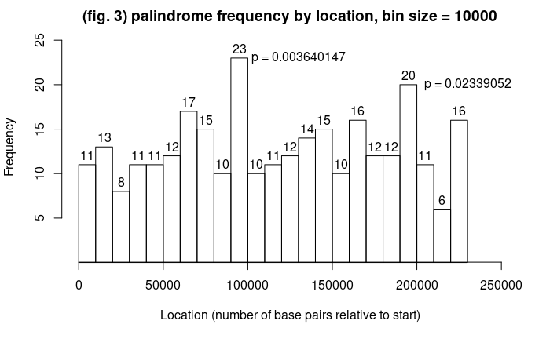

```r
#paste probability of the cluster of 20 in a bin size of 10000
#based on ppois()
text(x=230000, y = 20, labels = paste("p = 0.02339052"))
```

```r
#code for getting the listed probabilites is in the next chunk.
```

Notable Clusters:

```r
prob13 <- 1 - ppois(12, lambda = (2500*296)/229354)
# probability of 13 or greater occurrences of palindromes
# with histogram bins of 2500 base pairs
show(prob13)
```

```
[1] 3.382937e-05
```

```r
# 3.401389e-05
prob10 <- 1 - ppois(9, lambda = (2500*296)/229354)
# probability of 10 or greater occurrences of palindromes
# with histogram bins of 2500 base pairs
show(prob10)
```

```
[1] 0.001868974
```

```r
# 0.00187622
#################################################################################
prob18 <- 1 - ppois(18, lambda = (5000*296)/229354)
# probability of 18 or greater occurences of palindromes
# with bins of 5000 base pairs
show(prob18)
```

```
[1] 4.599756e-05
```

```r
# 4.599756e-05
prob12 <- 1 - ppois(12, lambda = (5000*296)/229354)
# probability of 12 or greater occurences of palindromes
# with bins of 5000 base pairs
show(prob12)
```

```
[1] 0.01520251
```

```r
# 0.01520251
#################################################################################
prob23 <- 1 - ppois(23, lambda = (10000*296)/229354)
# probability of 23 or greater occurences of palindromes
# with bins of 10000 base pairs
show(prob23)
```

```
[1] 0.003640147
```

```r
# 0.003640147
prob20 <- 1 - ppois(20, lambda = (10000*296)/229354)
# probability of 20 or greater occurences of palindromes
# with bins of 10000 base pairs
show(prob20)
```

```
[1] 0.02339052
```

```r
# 0.02339052
```

Figures 4 through 6 show probability density plots of cluster sizes based on bins of 2500, 5000, and 10,000. These show the point probability of a certain amount of palindromes in a given bin, meaning the probability that that many palindromes occur in that size of bin. This differes from cumulative probability in that it is no longer the probability of that many palindromes or more in a bin, but simply that specific amount of palindromes in a bin. Point probability utilizes the dpois() function. Red and blue lines were added for quantiles of probability defined by qpois(). For example, qpois(c(0.025, 0.5, 0.975), lambda=2500*296/229354) will cause lines to be added on the x axis based on quantiles of probability. The quantiles there are set to p = 0.025, 0.5, and 0.975. This means that there is a 97.5% probability that the number of palindromes in the bin is not beyond the 3rd quantile, and the red line gets placed at that point. Consequently, fig. 4 shows that it would not be very unusual to see any number of palindromes less than 7 in a bin size of 2500. Fig 5. shows that 12 or more clusters would indicate a suspect area of improbable clustering given bin sizes of 5000. Fig. 6 shows that for bins of 10,000 then the threshold for an unusual cluster would be at 20 palindromes.

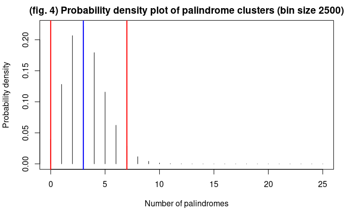

```r
#binning by 2500 base pairs
plot(0:25, dpois(0:25, lambda=2500*296/229354), type='h',
     ylab="Probability density", xlab="Number of palindromes",
     main = "(fig. 4) Probability density plot of palindrome clusters (bin size 2500)")
abline(v = qpois(c(0.025, 0.5, 0.975), lambda=2500*296/229354), col=c("red", "blue", "red"), lwd=2)
```

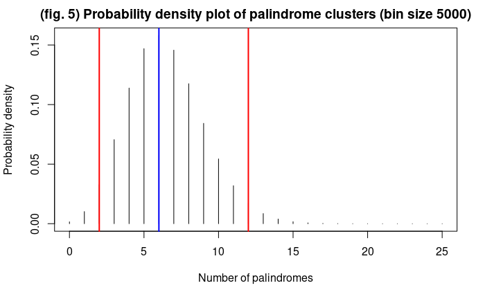

```r
#binning by 5000 base pairs
plot(0:25, dpois(0:25, lambda=5000*296/229354), type='h',
     ylab="Probability density", xlab="Number of palindromes",
    main = "(fig. 5) Probability density plot of palindrome clusters (bin size 5000)")
abline(v = qpois(c(0.025, 0.5, 0.975), lambda=5000*296/229354), col=c("red", "blue", "red"), lwd=2)
```

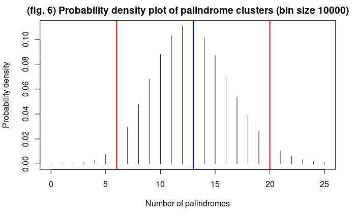

```r
#binning by 10000 base pairs
plot(0:25, dpois(0:25, lambda=10000*296/229354), type='h',
     ylab="Probability density", xlab="Number of palindromes",
    main = "(fig. 6) Probability density plot of palindrome clusters (bin size 10000)")
abline(v = qpois(c(0.025, 0.5, 0.975), lambda=10000*296/229354), col=c("red", "blue", "red"), lwd=2)
```

```r
## usage:
## cmv.counts<-slide.window(hcmv, 230000, blocksize=3000, incr=400)
## plot(count ~ block.mid, data=cmv.counts, type="l")
slide.window<-function(seqdata, total.length, blocksize=500, incr=100){
  block.right<-seq(blocksize,total.length, by=incr)
  block.left<-block.right-blocksize+1
  block.mid<-(block.right+block.left)/2
  nblocks<-length(block.right)
  count<-numeric(nblocks)
  rate<-numeric(nblocks)

  for(i in 1:nblocks) {
    focal<-seqdata[seqdata>block.left[i] & seqdata < block.right[i]]
    count[i]<-length(focal)
    rate[i]<-count[i] / blocksize
    # alternatively
    # count[i] <- sum(seqdata>block.left[i] & seqdata < block.right[i])
  }
  data.frame(count, rate, block.left, block.mid, block.right)
}

plot(rate ~ block.mid, data=slide.window(cmv, 230000, blocksize=2500, incr=1000), type="l")
lines(rate ~ block.mid, data=slide.window(cmv, 230000, blocksize=5000, incr=1000), col="green")
```

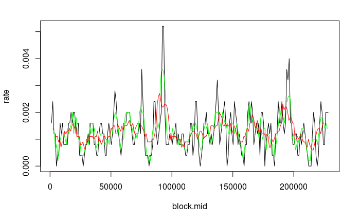

```r
lines(rate ~ block.mid, data=slide.window(cmv, 230000, blocksize=10000, incr=1000), col="red")
```

```r
#lines(rate ~ block.mid, data=slide.window(cmv, 230000, blocksize=36000, incr=1000), col="red")
```

However, what if binning for the histograms had been cutting apart groups of palindromes and hiding potential clusters? To deal with this possibility, I used a sliding window function that would incorporate neighboring data in the blocks in increments of 1000. This allows for a more continual depiction of the palindrome concentration fluctuation. I chose increments of 1000 because if it were too big it would be encroaching on entire other bins and misrepresent the binning, not helping analyze the histograms. Additionally, 1000 is small enough to help highlight previously hidden groups while being big enough to not too closely match the histogram. If the increment value were 20, for example, the sliding window would look almost exactly like our histogram. If it were 5000, it would include entire other bins for the 2500 and 5000 bin sizes and be far too generalized to see hidden groups of palindromes. Figures 7 through 9 show the sliding window analyses plotted over our previous histograms. A horizontal line is added at the 3rd quantile cutoff that we found and showed in figures 4 through 6. There are now not only the notable two spikes that were observed in the histograms, but each graph now has at least one new area of potential clustering. Figure 7 shows that around 75,000 and 135,000 there are two more notable groups. It also shows that following 50,000 there is a less notable uptick, which might be considered after the others. However, figure 8 with bin size of 5000 does not show any of those clusters but rather one near 160,000 that the bin size of 2500 did not find. This suggests that the clusters in figure 7 might be more tightly packed, and the cluster in figure 8 is a little more spread out.

```r
#plot the histogram with bins of 2500 like before but with no labels and grey bars
hist(cmv, breaks=seq(0, 230000, by=2500), xlim = c(1, 250000), ylim = c(1, 15),
     main = "(fig. 7) palindrome frequency by location, bin size = 2500",
     xlab = "Location", border = FALSE, col = "Grey")
#add the sliding window analyses over the histogram
lines(count ~ block.mid, data=slide.window(cmv, 230000, blocksize=2500, incr=1000), type="l", col = "black")
```

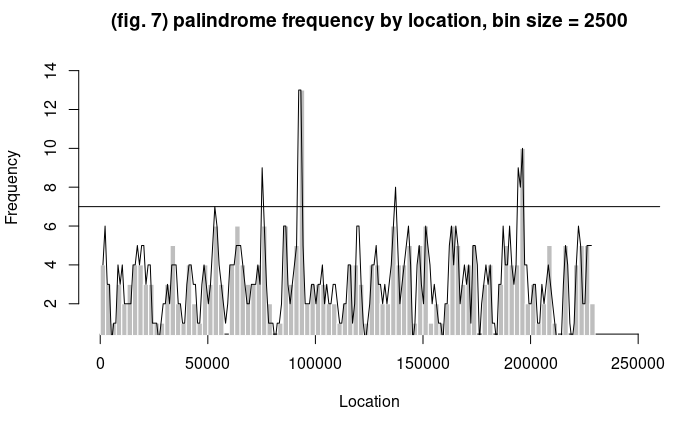

```r
#add the probability cutoff given by the probability distribution plots above
abline(h = 7)
```

```r
#plot the histogram with bins of 5000 like before, but remove labels and change the bars to grey
hist(cmv, breaks=seq(0, 230000, by=5000), xlim = c(1, 250000), ylim = c(1, 20),
     main = "(fig. 8) palindrome frequency by location, bin size = 5000",
     xlab = "Location", border = FALSE, col = "Grey")
#add the sliding window analysis over the histogram
lines(count ~ block.mid, data=slide.window(cmv, 230000, blocksize=5000, incr=1000), type="l", col = "black")
```

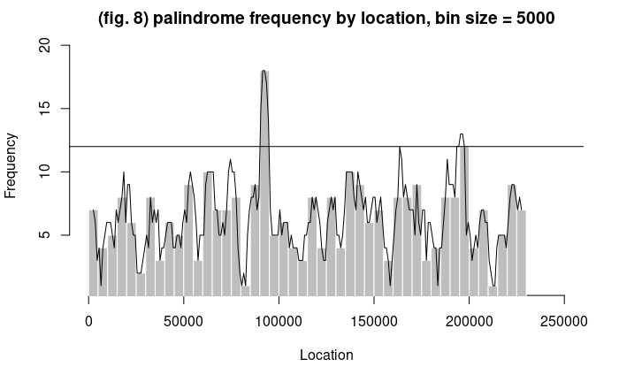

```r
#plot probability cutoff given by probability distribution plots above
abline(h = 12)
```

```r
#plotting 10,000 bin size histogram, grey bars, no labels
hist(cmv, breaks=seq(0, 230000, by=10000), xlim = c(1, 250000), ylim = c(1, 30),
     main = "(fig. 9) palindrome frequency by location, bin size = 10000",
     xlab = "Location", border = FALSE, col = "Grey")
#adding sliding window
lines(count ~ block.mid, data=slide.window(cmv, 230000, blocksize=10000, incr=1000), type="l", col = "black")
```

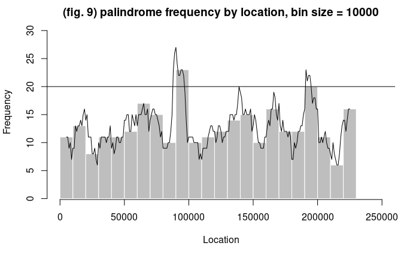

```r
#adding probability cutoff from prob distribution graph
abline(h = 20)
```

So far the count of palindromes has been the focus of discussion, but what about their spacing? It is possible to use the diff() function in R with a “lag” and “shape” that define a group size of palindrome clusters. The diff() function will show lagged differences between values, so we can use it to set group sizes. With those groups, pgamma() can be used to calculate the probability of the proximity of the group. The Pgamma function calculates the cumulative probability of the spacing of palindrome groups (whose size is given by the diff() function). Applying our use of pgamma(), figure 10 shows a plot of the probability of distances in palindrome groups based on a group size (lag) of 7. The probability is on a logarithmic scale to make it more readable. The more negative the y value, the less probable the result. Once more, we see notable dips in probability of the clusters around 90,000 and 190,000. The other notable clusters discovered with the sliding window analysis are evident too, though they do not appear as improbable. This shows that these clusters are less likely to have been grouped so tightly due to chance than other clusters in the data. I chose a lag of 7 because lower lags made it slightly harder to observe the difference in magnitude of the spikes. However, a larger lag made it hard to observe the smaller fluctuations such as the ones at 75,000 and 135,000.

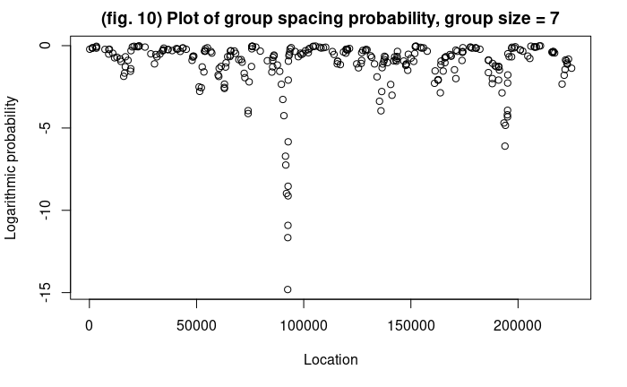

```r
plot(cmv[1:(296-7)], pgamma(diff(cmv, lag=7), shape=7, rate=296/229354, log=T),
     xlab = c("Location"), ylab = c("Logarithmic probability"), main = "(fig. 10) Plot of group spacing probability, group size = 7")
```

Below are groups of improbable clusters based on their group size (lag), and probability (p). The clusters at 90,000 and 190,000 appear in all of these lists. The cluster at 75,000 appears with lag of 4 and 5, with p < 0.01 meaning it is also quite improbable. If the cutoff probability is made slightly more lenient, p = 0.05, then more clusters appear around 50,000, 135,000, and 160,000 but these are not as strong of candidates due to their requirement of a smaller group sizing and more lenient probability cutoff. These were observed in the sliding window analyses though.

```r
# show the location of various group sizes with improbable proximity within group
# based on pgamma (cumulative probability) of the diff() (setting group sizes).
#lag = 4, p < .05
cmv[1:(296-4)][ which(pgamma(diff(cmv, lag=4), shape=4,
                             rate=296/229354) < 0.05) ]
```

```
 [1]  53439  62946  75622  75775  85130  85513  91637  91953  92526  92570  92643  92701  92709  92747  92783  92859
[17] 119665 142991 151314 173863 194111 195032 195112 195117 221949
```

```r
#lag = 5, p < .05
cmv[1:(296-5)][ which(pgamma(diff(cmv, lag=5), shape=5,
                             rate=296/229354) < 0.05) ]
```

```
 [1]  52629  74541  75622  85130  91490  91637  91953  92526  92570  92643  92701  92709  92747  92783  92859 136405
[17] 142416 162682 193902 194111 195032 195112 221527
```

```r
#lag = 7, p < .05
cmv[1:(296-7)][ which(pgamma(diff(cmv, lag=7), shape=7,
                             rate=296/229354) < 0.05) ]
```

```
 [1]  74053  74059  90251  90763  91490  91637  91953  92526  92570  92643  92701  92709  92747 135361 136051 141201
[17] 193447 193902 194111 195032 195112 195117
```

```r
#lag = 4, p < .01
cmv[1:(296-4)][ which(pgamma(diff(cmv, lag=4), shape=4,
                             rate=296/229354) < 0.01) ]
```

```
 [1]  75622  75775  85513  92526  92570  92643  92701  92709  92747 173863 195032 195112
```

```r
#lag = 5, p < .01
cmv[1:(296-5)][ which(pgamma(diff(cmv, lag=5), shape=5,
                             rate=296/229354) < 0.01) ]
```

```
 [1]  75622  91953  92526  92570  92643  92701  92709  92747  92783 195032 195112
```

```r
#lag = 7, p < .01
cmv[1:(296-7)][ which(pgamma(diff(cmv, lag=7), shape=7,
                             rate=296/229354) < 0.01) ]
```

```
 [1]  91490  91637  91953  92526  92570  92643  92701  92709  92747 193447 193902 194111
```

```r
#lag = 9, p < .01
cmv[1:(296-9)][ which(pgamma(diff(cmv, lag=9), shape=9,
                             rate=296/229354) < 0.01) ]
```

```
 [1]  90251  90763  91490  91637  91953  92526  92570  92643  92701 193447 195032
```

Given this information, I would rank candidate locations as such:

1. ~90,000 to ~95,000 (first at 90,251)
2. ~193,000 to ~198,000 (first at 193,447)
3. ~75,000 to ~77,500 (first at 74,053)
4. ~135,000 to ~140,000 (first at 135,361)
5. ~160,000 to 165,000 (first at 162,682)

Where rank 1 is most suspect, and the rest follow in a descending order. The location of the first palindrome is given as a fairly early observation of the beginning of a group to ensure it is not exluded. The less probable and less apparent groups, like the ones only seen in the sliding window or in the pgamma probability groups, are included as notable clusters in the event that the dramatic first two do not yield the site of replication. Ranks 3, 4, and 5 are all clusters that reach the probability cutoff drawn on figures 7 and 8. While not as improbable as the clusters around 90,000 and 190,000, they are still worth noting. It is also worth noting that in saying a cluster is improbable, it is only so improbable given that it is the product of chance. This means that highly improbable events are indicative of a process acting to cause them.